# **Male *CS* courtship behaviour when paired with female aDN>TNT**

Aaron M. Allen

5th December 2020

# **Load packages**

Loading in the packages that we'll need for the analysis.

```r
library(tidyverse)
library(survminer)
library(survival)
library(data.table)
library(ggpubr)
library(zoo)
library(ggbeeswarm)
library(cowplot)
```

# **Load data**

This first bit is a lot of data import and manipulation to get it already to plot the courtship features.

First we'll load in the "key" tables with the genotypes, and do a little cleaning.

```r
genotypes <- read_csv("female_adn_ids.csv",col_names = TRUE)
head(genotypes)
```

| video | arena | fly_id | copulation_time | genotype |
| --- | --- | --- | --- | --- |
| Megan-2019_03_06_Courtship-DsxVglutTNT_Female_1234_8 | 3 | 5 | 331 | a |
| Megan-2019_03_06_Courtship-DsxVglutTNT_Female_1234_8 | 4 | 7 | 1237 | a |
| Megan-2019_03_06_Courtship-DsxVglutTNT_Female_1234_8 | 9 | 17 | 343 | a |
| Megan-2019_03_06_Courtship-DsxVglutTNT_Female_1234_8 | 10 | 19 | 736 | a |
| Megan-2019_03_06_Courtship-DsxVgluTNT_Female_134_1 | 4 | 7 | 337 | a |
| Megan-2019_03_06_Courtship-DsxVgluTNT_Female_134_1 | 5 | 10 | 162 | a |

One pair of flies didnt' copulate after one hour.

```r
sum(is.na(genotypes$copulation_time))
```

```
## [1] 1
```

Copulation times were deduced from an mp4 video, which starts before the tracking and so needs to be offset.

```r
video_offset <- read_csv("video_offset.csv",col_names = TRUE)
head(video_offset)
```

| video | offset |
| --- | --- |
| Megan-2019_03_06_Courtship-DsxVglutTNT_Male_123_3 | 30 |
| Megan-2019_03_06_Courtship-DsxVglutTNT_Male_1234_7 | 30 |
| Megan-2019_03_06_Courtship-DsxVglutTNT_Male_1234_6 | 30 |
| Megan-2019_03_06_Courtship-DsxVglutTNT_Male_1234_9 | 30 |
| Megan-2019_03_06_Courtship-DsxVglutTNT_Male_1234_2 | 5 |
| Megan-2019_03_06_Courtship-DsxVglutTNT_Male_1234_5 | 6 |

```r
genotypes <- left_join(genotypes,video_offset)
genotypes <- genotypes %>%
  mutate(mp4_cop_time=copulation_time,
        copulation_time=mp4_cop_time-offset)
head(genotypes)
```

| video | arena | fly_id | copulation_time | genotype | offset | mp4_cop_time |
| --- | --- | --- | --- | --- | --- | --- |
| Megan-2019_03_06_Courtship-DsxVglutTNT_Female_1234_8 | 3 | 5 | 301 | a | 30 | 331 |
| Megan-2019_03_06_Courtship-DsxVglutTNT_Female_1234_8 | 4 | 7 | 1207 | a | 30 | 1237 |
| Megan-2019_03_06_Courtship-DsxVglutTNT_Female_1234_8 | 9 | 17 | 313 | a | 30 | 343 |
| Megan-2019_03_06_Courtship-DsxVglutTNT_Female_1234_8 | 10 | 19 | 706 | a | 30 | 736 |
| Megan-2019_03_06_Courtship-DsxVgluTNT_Female_134_1 | 4 | 7 | 331 | a | 6 | 337 |
| Megan-2019_03_06_Courtship-DsxVgluTNT_Female_134_1 | 5 | 10 | 156 | a | 6 | 162 |

One fly had already started to copulate by the time the tracking started.

```r
sum(genotypes$copulation_time<0,na.rm = T)
```

```
## [1] 1
```

```r
min(genotypes$copulation_time,na.rm = T)
```

```
## [1] -3
```

```r
genotypes$copulation_time[genotypes$copulation_time<0] <- 0
sum(genotypes$copulation_time<0,na.rm = T)
```

```
## [1] 0
```

We also want to populate this table with the Id numbers for the matched females in each chamber. We are simply duplicating the `genotypes` table and if the male `fly_id` was odd, then we increment the female Id, and if the male `fly_id` was even then we decrement the Id. Finally we change the male genotype to "*CS*".

```r
genotypes <- genotypes %>% mutate(treatment = genotype)
female_genotypes <- genotypes
even_ids <- (genotypes$fly_id %% 2) == 0
odd_ids <- (genotypes$fly_id %% 2) != 0
female_genotypes$fly_id[even_ids] = female_genotypes$fly_id[even_ids] - 1
female_genotypes$fly_id[odd_ids] = female_genotypes$fly_id[odd_ids] + 1
genotypes$genotype <- "CS"
head(female_genotypes)
```

| video | arena | fly_id | copulation_time | genotype | offset | mp4_cop_time | treatment |
| --- | --- | --- | --- | --- | --- | --- | --- |
| Megan-2019_03_06_Courtship-DsxVglutTNT_Female_1234_8 | 3 | 6 | 301 | a | 30 | 331 | a |
| Megan-2019_03_06_Courtship-DsxVglutTNT_Female_1234_8 | 4 | 8 | 1207 | a | 30 | 1237 | a |
| Megan-2019_03_06_Courtship-DsxVglutTNT_Female_1234_8 | 9 | 18 | 313 | a | 30 | 343 | a |
| Megan-2019_03_06_Courtship-DsxVglutTNT_Female_1234_8 | 10 | 20 | 706 | a | 30 | 736 | a |
| Megan-2019_03_06_Courtship-DsxVgluTNT_Female_134_1 | 4 | 8 | 331 | a | 6 | 337 | a |
| Megan-2019_03_06_Courtship-DsxVgluTNT_Female_134_1 | 5 | 9 | 156 | a | 6 | 162 | a |

Now we merge the male and female `genotypes` tables.

```r
all_genotypes <- bind_rows(genotypes,female_genotypes)
all_genotypes <- all_genotypes %>%
  unite("uni_fly",video,fly_id,remove = FALSE)
head(all_genotypes)
```

| uni_fly | video | arena | fly_id | copulation_time | genotype | offset | mp4_cop_time | treatment |
| --- | --- | --- | --- | --- | --- | --- | --- | --- |
| Megan-2019_03_06_Courtship-DsxVglutTNT_Female_1234_8_5 | Megan-2019_03_06_Courtship-DsxVglutTNT_Female_1234_8 | 3 | 5 | 301 | CS | 30 | 331 | a |
| Megan-2019_03_06_Courtship-DsxVglutTNT_Female_1234_8_7 | Megan-2019_03_06_Courtship-DsxVglutTNT_Female_1234_8 | 4 | 7 | 1207 | CS | 30 | 1237 | a |
| Megan-2019_03_06_Courtship-DsxVglutTNT_Female_1234_8_17 | Megan-2019_03_06_Courtship-DsxVglutTNT_Female_1234_8 | 9 | 17 | 313 | CS | 30 | 343 | a |
| Megan-2019_03_06_Courtship-DsxVglutTNT_Female_1234_8_19 | Megan-2019_03_06_Courtship-DsxVglutTNT_Female_1234_8 | 10 | 19 | 706 | CS | 30 | 736 | a |
| Megan-2019_03_06_Courtship-DsxVgluTNT_Female_134_1_7 | Megan-2019_03_06_Courtship-DsxVgluTNT_Female_134_1 | 4 | 7 | 331 | CS | 6 | 337 | a |
| Megan-2019_03_06_Courtship-DsxVgluTNT_Female_134_1_10 | Megan-2019_03_06_Courtship-DsxVgluTNT_Female_134_1 | 5 | 10 | 156 | CS | 6 | 162 | a |

And now we can read in all the csv files with all the raw tracking and JAABA annotated behaviours.

```r
rawdata_list <- list.files("./",recursive = TRUE) %>% str_subset("_ALLDATA.csv")
all_rawdata <- tibble()
for (rawdata_file in rawdata_list) {
  temp <- fread(input = paste0("./",rawdata_file), showProgress = FALSE)
  all_rawdata <- bind_rows(all_rawdata,temp)
}
head(all_rawdata)
```

| FileName | StartPosition | Arena | Id | Frame | Approaching | Contact | Copulation | Encircling | Facing | Turning | WingGesture | vel__mmpers | ang_vel__radpers | min_wing_ang__rad | max_wing_ang__rad | mean_wing_length__mm | axis_ratio__ratio | fg_body_ratio__ratio | contrast__ | dist_to_wall__mm | dist_to_other__mm | angle_between__rad | facing_angle__rad | leg_dist__mm | pos_x__px | pos_y__px | ori__rad | major_axis_len__px | minor_axis_len__px | … |
| --- | --- | --- | --- | --- | --- | --- | --- | --- | --- | --- | --- | --- | --- | --- | --- | --- | --- | --- | --- | --- | --- | --- | --- | --- | --- | --- | --- | --- | --- | --- |
| Megan-2019_03_06_Courtship-DsxVgluTNT_Female_134_1 | r | 1 | 1 | 1 | 0 | 0 | 0 | 0 | 0 | 0 | 0 | 0.272168224 | 0.40634155 | 0.05030346 | 0.07337640 | 1.890318 | 3.117498 | 2.427673 | 0.4609097 | 4.627088 | 11.77255 | 1.115961 | 0.1354554 | 9.021026 | 521.4308 | 287.9182 | 2.266777 | 36.06743 | 11.56935 | … |
| Megan-2019_03_06_Courtship-DsxVgluTNT_Female_134_1 | r | 1 | 1 | 2 | 0 | 0 | 0 | 0 | 0 | 0 | 0 | 0.272168224 | 0.31514002 | 0.05069805 | 0.06700893 | 1.892818 | 3.127066 | 2.441673 | 0.4619226 | 4.560551 | 11.76860 | 1.128618 | 0.1325115 | 9.042249 | 521.6198 | 287.8435 | 2.250523 | 36.07556 | 11.48349 | … |
| Megan-2019_03_06_Courtship-DsxVgluTNT_Female_134_1 | r | 1 | 1 | 3 | 0 | 0 | 0 | 0 | 0 | 0 | 0 | 0.098673589 | 0.12600767 | 0.04606164 | 0.06562634 | 1.898013 | 3.115926 | 2.427411 | 0.4640119 | 4.560551 | 11.75565 | 1.179771 | 0.1249254 | 9.042249 | 521.6625 | 287.8656 | 2.252184 | 36.26479 | 11.66919 | … |
| Megan-2019_03_06_Courtship-DsxVgluTNT_Female_134_1 | r | 1 | 1 | 4 | 0 | 0 | 0 | 0 | 0 | 0 | 0 | 0.089102599 | 0.06933184 | 0.04979006 | 0.06768241 | 1.895236 | 3.108913 | 2.415063 | 0.4627594 | 4.560551 | 11.71599 | 1.306768 | 0.1166853 | 9.066070 | 521.6038 | 287.8082 | 2.251600 | 36.12870 | 11.62923 | … |
| Megan-2019_03_06_Courtship-DsxVgluTNT_Female_134_1 | r | 1 | 1 | 5 | 0 | 0 | 0 | 0 | 0 | 0 | 0 | 0.113500072 | 0.12842980 | 0.04682306 | 0.07039884 | 1.899734 | 3.101694 | 2.402746 | 0.4619372 | 4.560551 | 11.64131 | 1.433916 | 0.1118419 | 9.100580 | 521.5452 | 287.7383 | 2.259862 | 36.34950 | 11.67111 | … |
| Megan-2019_03_06_Courtship-DsxVgluTNT_Female_134_1 | r | 1 | 1 | 6 | 0 | 0 | 0 | 0 | 0 | 0 | 0 | 0.007072369 | 0.12477524 | 0.03584863 | 0.06939291 | 1.912436 | 3.090844 | 2.393262 | 0.4636401 | 4.560551 | 11.53086 | 1.492881 | 0.1069669 | 9.119509 | 521.5309 | 287.7469 | 2.256422 | 36.18517 | 11.78252 | … |

Define a few functions to compute the relative x and y postions of each fly in each chamber.

```r
# calculates relative y value based on data from feat.mat
calculate_yrel <- function(theta,dist){
  yrel=dist*cos(theta)
  return(yrel)
}
calculate_xrel <- function(ori,xmale,xfemale,yrel,ppm=14.85){
  xmale_mm=xmale/ppm
  xfemale_mm=xfemale/ppm
  xrel = (xfemale_mm - (cos(ori)*yrel+xmale_mm))/(sin(ori))
  return(xrel)
}
calculate_xrel_abs <- function(theta,dist){
  xrel=dist*sin(theta)
  return(xrel)
}
```

And calculate those relative x and y positions.

```r
all_rawdata <- all_rawdata %>%
  arrange(FileName,Arena,Frame)

all_rawdata$rel_y_other <- NA
all_rawdata$rel_x_other <- NA
all_rawdata$rel_x_abs_other <- NA
all_rawdata$rel_x_abs_corr_other <- NA

all_rawdata$rel_y_other[seq(1,nrow(all_rawdata),2)] = calculate_yrel(all_rawdata$facing_angle__rad[seq(1,nrow(all_rawdata),2)],
                                                         all_rawdata$dist_to_other__mm[seq(1,nrow(all_rawdata),2)])

all_rawdata$rel_x_other[seq(1,nrow(all_rawdata),2)] = calculate_xrel(ori = all_rawdata$ori__rad[seq(1,nrow(all_rawdata),2)],
                                                         xmale = all_rawdata$pos_x__px[seq(1,nrow(all_rawdata),2)],
                                                         xfemale = all_rawdata$pos_x__px[seq(2,nrow(all_rawdata),2)],
                                                         yrel = calculate_yrel(all_rawdata$facing_angle__rad[seq(1,nrow(all_rawdata),2)],
                                                                               all_rawdata$dist_to_other__mm[seq(1,nrow(all_rawdata),2)]))

all_rawdata$rel_x_abs_other[seq(1,nrow(all_rawdata),2)] = calculate_xrel_abs(all_rawdata$facing_angle__rad[seq(1,nrow(all_rawdata),2)],
                                                                 all_rawdata$dist_to_other__mm[seq(1,nrow(all_rawdata),2)])


all_rawdata$rel_y_other[seq(2,nrow(all_rawdata),2)] = calculate_yrel(all_rawdata$facing_angle__rad[seq(2,nrow(all_rawdata),2)],
                                                         all_rawdata$dist_to_other__mm[seq(2,nrow(all_rawdata),2)])

all_rawdata$rel_x_other[seq(2,nrow(all_rawdata),2)] = calculate_xrel(ori = all_rawdata$ori__rad[seq(2,nrow(all_rawdata),2)],
                                                         xmale = all_rawdata$pos_x__px[seq(2,nrow(all_rawdata),2)],
                                                         xfemale = all_rawdata$pos_x__px[seq(1,nrow(all_rawdata),2)],
                                                         yrel = calculate_yrel(all_rawdata$facing_angle__rad[seq(2,nrow(all_rawdata),2)],
                                                                               all_rawdata$dist_to_other__mm[seq(2,nrow(all_rawdata),2)]))

all_rawdata$rel_x_abs_other[seq(2,nrow(all_rawdata),2)] = calculate_xrel_abs(all_rawdata$facing_angle__rad[seq(2,nrow(all_rawdata),2)],
                                                                 all_rawdata$dist_to_other__mm[seq(2,nrow(all_rawdata),2)])


all_rawdata$rel_x_abs_corr_other[which(all_rawdata$rel_x_other<0)] = -all_rawdata$rel_x_abs_other[which(all_rawdata$rel_x_other<0)]
all_rawdata$rel_x_abs_corr_other[which(all_rawdata$rel_x_other>0)] = all_rawdata$rel_x_abs_other[which(all_rawdata$rel_x_other>0)]

head(all_rawdata)
```

| FileName | StartPosition | Arena | Id | Frame | Approaching | Contact | Copulation | Encircling | Facing | Turning | WingGesture | vel__mmpers | ang_vel__radpers | min_wing_ang__rad | max_wing_ang__rad | mean_wing_length__mm | axis_ratio__ratio | fg_body_ratio__ratio | contrast__ | dist_to_wall__mm | dist_to_other__mm | angle_between__rad | facing_angle__rad | leg_dist__mm | pos_x__px | pos_y__px | ori__rad | major_axis_len__px | minor_axis_len__px | … |
| --- | --- | --- | --- | --- | --- | --- | --- | --- | --- | --- | --- | --- | --- | --- | --- | --- | --- | --- | --- | --- | --- | --- | --- | --- | --- | --- | --- | --- | --- | --- |
| Megan-2019_03_06_Courtship-DsxVgluTNT_Female_134_1 | r | 1 | 1 | 1 | 0 | 0 | 0 | 0 | 0 | 0 | 0 | 0.27216822 | 0.4063415 | 0.05030346 | 0.07337640 | 1.890318 | 3.117498 | 2.427673 | 0.4609097 | 4.627088 | 11.77255 | 1.115961 | 0.1354554 | 9.021026 | 521.4308 | 287.9182 | 2.266777 | 36.06743 | 11.56935 | … |
| Megan-2019_03_06_Courtship-DsxVgluTNT_Female_134_1 | l | 1 | 2 | 1 | 0 | 0 | 0 | 0 | 0 | 0 | 0 | 4.57570212 | 0.7710196 | 0.04660803 | 0.14326653 | 1.722322 | 3.006840 | 4.031142 | 0.4926996 | 1.758796 | 11.77255 | 1.115961 | 1.8901764 | 9.021026 | 393.1246 | 170.9135 | 1.150816 | 34.00204 | 11.30823 | … |
| Megan-2019_03_06_Courtship-DsxVgluTNT_Female_134_1 | r | 1 | 1 | 2 | 0 | 0 | 0 | 0 | 0 | 0 | 0 | 0.27216822 | 0.3151400 | 0.05069805 | 0.06700893 | 1.892818 | 3.127066 | 2.441673 | 0.4619226 | 4.560551 | 11.76860 | 1.128618 | 0.1325115 | 9.042249 | 521.6198 | 287.8435 | 2.250523 | 36.07556 | 11.48349 | … |
| Megan-2019_03_06_Courtship-DsxVgluTNT_Female_134_1 | l | 1 | 2 | 2 | 0 | 0 | 0 | 0 | 0 | 0 | 0 | 4.57570212 | 0.6107926 | 0.05267560 | 0.09875482 | 1.739361 | 3.156727 | 3.835906 | 0.4924988 | 1.698978 | 11.76860 | 1.128618 | 1.8804635 | 9.042249 | 395.4393 | 168.7377 | 1.119975 | 36.50783 | 11.33239 | … |
| Megan-2019_03_06_Courtship-DsxVgluTNT_Female_134_1 | r | 1 | 1 | 3 | 0 | 0 | 0 | 0 | 0 | 0 | 0 | 0.09867359 | 0.1260077 | 0.04606164 | 0.06562634 | 1.898013 | 3.115926 | 2.427411 | 0.4640119 | 4.560551 | 11.75565 | 1.179771 | 0.1249254 | 9.042249 | 521.6625 | 287.8656 | 2.252184 | 36.26479 | 11.66919 | … |
| Megan-2019_03_06_Courtship-DsxVgluTNT_Female_134_1 | l | 1 | 2 | 3 | 0 | 0 | 0 | 0 | 0 | 0 | 0 | 3.32988661 | 1.3633042 | 0.04834941 | 0.08899679 | 1.734456 | 3.200113 | 3.730316 | 0.4935111 | 1.698978 | 11.75565 | 1.179771 | 1.8368963 | 9.042249 | 396.2387 | 167.7387 | 1.114771 | 36.33112 | 11.43576 | … |

Using the copulation frames from the `all_genotypes` table we can subset the raw tracking data to remove all copulatory frames. We are then left with the non-copulatory frames.

```r
all_rawdata <- all_rawdata %>%
  unite("uni_fly",FileName,Id,remove = FALSE)

non_cop_frames <- tibble()
flies <- unique(all_genotypes$uni_fly)
for (fly in flies) {
  cop_time <- all_genotypes$copulation_time[all_genotypes$uni_fly==fly]
  cop_time <- replace_na(cop_time,900)
  cop_time <- cop_time*25
  temp0 <- all_rawdata %>%
    filter(uni_fly == fly) %>%
    slice(1:cop_time)
  non_cop_frames <- bind_rows(non_cop_frames,temp0)
}
head(non_cop_frames)
```

| uni_fly | FileName | StartPosition | Arena | Id | Frame | Approaching | Contact | Copulation | Encircling | Facing | Turning | WingGesture | vel__mmpers | ang_vel__radpers | min_wing_ang__rad | max_wing_ang__rad | mean_wing_length__mm | axis_ratio__ratio | fg_body_ratio__ratio | contrast__ | dist_to_wall__mm | dist_to_other__mm | angle_between__rad | facing_angle__rad | leg_dist__mm | pos_x__px | pos_y__px | ori__rad | major_axis_len__px | … |
| --- | --- | --- | --- | --- | --- | --- | --- | --- | --- | --- | --- | --- | --- | --- | --- | --- | --- | --- | --- | --- | --- | --- | --- | --- | --- | --- | --- | --- | --- | --- |
| Megan-2019_03_06_Courtship-DsxVglutTNT_Female_1234_8_5 | Megan-2019_03_06_Courtship-DsxVglutTNT_Female_1234_8 | r | 3 | 5 | 1 | 0 | 0 | 0 | 0 | 0 | 0 | 0 | 0.10796062 | 0.17386255 | 0.05885103 | 0.19377787 | 1.594722 | 3.077303 | 2.088235 | 0.5266877 | 6.221945 | 5.521442 | 2.407049 | 2.980649 | 2.289562 | 1329.454 | 236.3627 | -0.2932893 | 35.19369 | … |
| Megan-2019_03_06_Courtship-DsxVglutTNT_Female_1234_8_5 | Megan-2019_03_06_Courtship-DsxVglutTNT_Female_1234_8 | r | 3 | 5 | 2 | 0 | 0 | 0 | 0 | 0 | 0 | 0 | 0.10796062 | 0.13471387 | 0.06658993 | 0.14549569 | 1.603510 | 3.061642 | 2.104683 | 0.5215905 | 6.221945 | 5.570293 | 2.431238 | 2.990040 | 2.259683 | 1329.453 | 236.2783 | -0.3002438 | 35.03612 | … |
| Megan-2019_03_06_Courtship-DsxVglutTNT_Female_1234_8_5 | Megan-2019_03_06_Courtship-DsxVglutTNT_Female_1234_8 | r | 3 | 5 | 3 | 0 | 0 | 0 | 0 | 0 | 0 | 0 | 0.01804455 | 0.09140908 | 0.06674199 | 0.11857974 | 1.611336 | 3.084669 | 2.122118 | 0.5260235 | 6.221945 | 5.577382 | 2.347630 | 2.986092 | 2.230457 | 1329.373 | 236.2890 | -0.3009345 | 35.43943 | … |
| Megan-2019_03_06_Courtship-DsxVglutTNT_Female_1234_8_5 | Megan-2019_03_06_Courtship-DsxVglutTNT_Female_1234_8 | r | 3 | 5 | 4 | 0 | 0 | 0 | 0 | 0 | 0 | 0 | 0.07237463 | 0.10978939 | 0.05652956 | 0.10236726 | 1.617636 | 3.085103 | 2.146849 | 0.5286387 | 6.221945 | 5.604834 | 2.163873 | 2.965036 | 2.212832 | 1329.500 | 236.3783 | -0.2946450 | 35.21340 | … |
| Megan-2019_03_06_Courtship-DsxVglutTNT_Female_1234_8_5 | Megan-2019_03_06_Courtship-DsxVglutTNT_Female_1234_8 | r | 3 | 5 | 5 | 0 | 0 | 0 | 0 | 0 | 0 | 0 | 0.06588194 | 0.16536620 | 0.04705655 | 0.09287322 | 1.608288 | 3.049301 | 2.157707 | 0.5201904 | 6.221945 | 5.648117 | 1.997105 | 2.939302 | 2.252275 | 1329.469 | 236.2848 | -0.2989415 | 35.02093 | … |
| Megan-2019_03_06_Courtship-DsxVglutTNT_Female_1234_8_5 | Megan-2019_03_06_Courtship-DsxVglutTNT_Female_1234_8 | r | 3 | 5 | 6 | 0 | 0 | 0 | 0 | 0 | 0 | 0 | 0.04039757 | 0.22837212 | 0.05180273 | 0.10872581 | 1.595995 | 3.043660 | 2.145721 | 0.5182594 | 6.231777 | 5.651837 | 1.842625 | 2.915277 | 2.310377 | 1329.560 | 236.3713 | -0.2873656 | 34.81374 | … |

Now we can join the genotype information from `all_genotypes` with the `non_cop_frames` table.

```r
non_cop_frames <- non_cop_frames %>%
  full_join(x = non_cop_frames, y = all_genotypes, by = c("uni_fly"="uni_fly")) %>%
  select(-StartPosition) %>%
  select(-copulation_time) %>%
  select(-offset) %>%
  select(-mp4_cop_time) %>%
  select(-fly_id) %>%
  select(-video) %>%
  mutate(sex = if_else(genotype == "CS","male","female"))
head(non_cop_frames)
```

| uni_fly | FileName | Arena | Id | Frame | Approaching | Contact | Copulation | Encircling | Facing | Turning | WingGesture | vel__mmpers | ang_vel__radpers | min_wing_ang__rad | max_wing_ang__rad | mean_wing_length__mm | axis_ratio__ratio | fg_body_ratio__ratio | contrast__ | dist_to_wall__mm | dist_to_other__mm | angle_between__rad | facing_angle__rad | leg_dist__mm | pos_x__px | pos_y__px | ori__rad | major_axis_len__px | minor_axis_len__px | … |
| --- | --- | --- | --- | --- | --- | --- | --- | --- | --- | --- | --- | --- | --- | --- | --- | --- | --- | --- | --- | --- | --- | --- | --- | --- | --- | --- | --- | --- | --- | --- |
| Megan-2019_03_06_Courtship-DsxVglutTNT_Female_1234_8_5 | Megan-2019_03_06_Courtship-DsxVglutTNT_Female_1234_8 | 3 | 5 | 1 | 0 | 0 | 0 | 0 | 0 | 0 | 0 | 0.10796062 | 0.17386255 | 0.05885103 | 0.19377787 | 1.594722 | 3.077303 | 2.088235 | 0.5266877 | 6.221945 | 5.521442 | 2.407049 | 2.980649 | 2.289562 | 1329.454 | 236.3627 | -0.2932893 | 35.19369 | 11.43654 | … |
| Megan-2019_03_06_Courtship-DsxVglutTNT_Female_1234_8_5 | Megan-2019_03_06_Courtship-DsxVglutTNT_Female_1234_8 | 3 | 5 | 2 | 0 | 0 | 0 | 0 | 0 | 0 | 0 | 0.10796062 | 0.13471387 | 0.06658993 | 0.14549569 | 1.603510 | 3.061642 | 2.104683 | 0.5215905 | 6.221945 | 5.570293 | 2.431238 | 2.990040 | 2.259683 | 1329.453 | 236.2783 | -0.3002438 | 35.03612 | 11.54806 | … |
| Megan-2019_03_06_Courtship-DsxVglutTNT_Female_1234_8_5 | Megan-2019_03_06_Courtship-DsxVglutTNT_Female_1234_8 | 3 | 5 | 3 | 0 | 0 | 0 | 0 | 0 | 0 | 0 | 0.01804455 | 0.09140908 | 0.06674199 | 0.11857974 | 1.611336 | 3.084669 | 2.122118 | 0.5260235 | 6.221945 | 5.577382 | 2.347630 | 2.986092 | 2.230457 | 1329.373 | 236.2890 | -0.3009345 | 35.43943 | 11.42697 | … |
| Megan-2019_03_06_Courtship-DsxVglutTNT_Female_1234_8_5 | Megan-2019_03_06_Courtship-DsxVglutTNT_Female_1234_8 | 3 | 5 | 4 | 0 | 0 | 0 | 0 | 0 | 0 | 0 | 0.07237463 | 0.10978939 | 0.05652956 | 0.10236726 | 1.617636 | 3.085103 | 2.146849 | 0.5286387 | 6.221945 | 5.604834 | 2.163873 | 2.965036 | 2.212832 | 1329.500 | 236.3783 | -0.2946450 | 35.21340 | 11.35196 | … |
| Megan-2019_03_06_Courtship-DsxVglutTNT_Female_1234_8_5 | Megan-2019_03_06_Courtship-DsxVglutTNT_Female_1234_8 | 3 | 5 | 5 | 0 | 0 | 0 | 0 | 0 | 0 | 0 | 0.06588194 | 0.16536620 | 0.04705655 | 0.09287322 | 1.608288 | 3.049301 | 2.157707 | 0.5201904 | 6.221945 | 5.648117 | 1.997105 | 2.939302 | 2.252275 | 1329.469 | 236.2848 | -0.2989415 | 35.02093 | 11.53867 | … |
| Megan-2019_03_06_Courtship-DsxVglutTNT_Female_1234_8_5 | Megan-2019_03_06_Courtship-DsxVglutTNT_Female_1234_8 | 3 | 5 | 6 | 0 | 0 | 0 | 0 | 0 | 0 | 0 | 0.04039757 | 0.22837212 | 0.05180273 | 0.10872581 | 1.595995 | 3.043660 | 2.145721 | 0.5182594 | 6.231777 | 5.651837 | 1.842625 | 2.915277 | 2.310377 | 1329.560 | 236.3713 | -0.2873656 | 34.81374 | 11.50848 | … |

```r
fwrite(non_cop_frames, file = "non_copulatory_frames.csv",col.names = TRUE)
```

We calculate the the courtship per-frame courtship features from the JAABA annotations.

```r
non_cop_frames <- non_cop_frames %>%
  group_by(uni_fly) %>%
  mutate(
    Multitasking = (Approaching + Encircling + Contact + Turning + WingGesture),
    MultitaskingWithFacing = (Approaching + Encircling + Facing + Contact + Turning + WingGesture),
    Courtship = ifelse(Multitasking>=1, 1, 0),
    CourtshipWithFacing = ifelse(MultitaskingWithFacing>=1, 1, 0),
    MultitaskingWithCopulation = (Approaching + Encircling + Contact + Turning + WingGesture + Copulation),
    MultitaskingWithCopulationWithFacing = (Approaching + Encircling + Facing + Contact + Turning + WingGesture + Copulation),
    CourtshipAndCopulation = ifelse(MultitaskingWithCopulation>=1, 1, 0),
    CourtshipAndCopulationWthFacing = ifelse(MultitaskingWithCopulationWithFacing>=1, 1, 0),
    SmoothedCourtship = ifelse((rollmean(Courtship, 150, fill = c(0,0,0), align = c("left")))>0.5, 1, 0),
    SmoothedCopulation = ifelse((rollmean(Copulation, 1250, fill = c(0,0,0), align = c("center")))>0.5, 1, 0)
  )
head(non_cop_frames)
```

| uni_fly | FileName | Arena | Id | Frame | Approaching | Contact | Copulation | Encircling | Facing | Turning | WingGesture | vel__mmpers | ang_vel__radpers | min_wing_ang__rad | max_wing_ang__rad | mean_wing_length__mm | axis_ratio__ratio | fg_body_ratio__ratio | contrast__ | dist_to_wall__mm | dist_to_other__mm | angle_between__rad | facing_angle__rad | leg_dist__mm | pos_x__px | pos_y__px | ori__rad | major_axis_len__px | minor_axis_len__px | … |
| --- | --- | --- | --- | --- | --- | --- | --- | --- | --- | --- | --- | --- | --- | --- | --- | --- | --- | --- | --- | --- | --- | --- | --- | --- | --- | --- | --- | --- | --- | --- |
| Megan-2019_03_06_Courtship-DsxVglutTNT_Female_1234_8_5 | Megan-2019_03_06_Courtship-DsxVglutTNT_Female_1234_8 | 3 | 5 | 1 | 0 | 0 | 0 | 0 | 0 | 0 | 0 | 0.10796062 | 0.17386255 | 0.05885103 | 0.19377787 | 1.594722 | 3.077303 | 2.088235 | 0.5266877 | 6.221945 | 5.521442 | 2.407049 | 2.980649 | 2.289562 | 1329.454 | 236.3627 | -0.2932893 | 35.19369 | 11.43654 | … |
| Megan-2019_03_06_Courtship-DsxVglutTNT_Female_1234_8_5 | Megan-2019_03_06_Courtship-DsxVglutTNT_Female_1234_8 | 3 | 5 | 2 | 0 | 0 | 0 | 0 | 0 | 0 | 0 | 0.10796062 | 0.13471387 | 0.06658993 | 0.14549569 | 1.603510 | 3.061642 | 2.104683 | 0.5215905 | 6.221945 | 5.570293 | 2.431238 | 2.990040 | 2.259683 | 1329.453 | 236.2783 | -0.3002438 | 35.03612 | 11.54806 | … |
| Megan-2019_03_06_Courtship-DsxVglutTNT_Female_1234_8_5 | Megan-2019_03_06_Courtship-DsxVglutTNT_Female_1234_8 | 3 | 5 | 3 | 0 | 0 | 0 | 0 | 0 | 0 | 0 | 0.01804455 | 0.09140908 | 0.06674199 | 0.11857974 | 1.611336 | 3.084669 | 2.122118 | 0.5260235 | 6.221945 | 5.577382 | 2.347630 | 2.986092 | 2.230457 | 1329.373 | 236.2890 | -0.3009345 | 35.43943 | 11.42697 | … |
| Megan-2019_03_06_Courtship-DsxVglutTNT_Female_1234_8_5 | Megan-2019_03_06_Courtship-DsxVglutTNT_Female_1234_8 | 3 | 5 | 4 | 0 | 0 | 0 | 0 | 0 | 0 | 0 | 0.07237463 | 0.10978939 | 0.05652956 | 0.10236726 | 1.617636 | 3.085103 | 2.146849 | 0.5286387 | 6.221945 | 5.604834 | 2.163873 | 2.965036 | 2.212832 | 1329.500 | 236.3783 | -0.2946450 | 35.21340 | 11.35196 | … |
| Megan-2019_03_06_Courtship-DsxVglutTNT_Female_1234_8_5 | Megan-2019_03_06_Courtship-DsxVglutTNT_Female_1234_8 | 3 | 5 | 5 | 0 | 0 | 0 | 0 | 0 | 0 | 0 | 0.06588194 | 0.16536620 | 0.04705655 | 0.09287322 | 1.608288 | 3.049301 | 2.157707 | 0.5201904 | 6.221945 | 5.648117 | 1.997105 | 2.939302 | 2.252275 | 1329.469 | 236.2848 | -0.2989415 | 35.02093 | 11.53867 | … |
| Megan-2019_03_06_Courtship-DsxVglutTNT_Female_1234_8_5 | Megan-2019_03_06_Courtship-DsxVglutTNT_Female_1234_8 | 3 | 5 | 6 | 0 | 0 | 0 | 0 | 0 | 0 | 0 | 0.04039757 | 0.22837212 | 0.05180273 | 0.10872581 | 1.595995 | 3.043660 | 2.145721 | 0.5182594 | 6.231777 | 5.651837 | 1.842625 | 2.915277 | 2.310377 | 1329.560 | 236.3713 | -0.2873656 | 34.81374 | 11.50848 | … |

```r
fwrite(non_cop_frames, file = "non_copulatory_frames_with_summary_features.csv",col.names = TRUE)
```

Just double checking our column names.

```r
colnames(non_cop_frames)
```

```
##  [1] "uni_fly"
##  [2] "FileName"
##  [3] "Arena"
##  [4] "Id"
##  [5] "Frame"
##  [6] "Approaching"
##  [7] "Contact"
##  [8] "Copulation"
##  [9] "Encircling"
## [10] "Facing"
## [11] "Turning"
## [12] "WingGesture"
## [13] "vel__mmpers"
## [14] "ang_vel__radpers"
## [15] "min_wing_ang__rad"
```

[output cut: 63 more lines]

Based on the per-frame courtship features we can now calculate the courtship initiation using the first instance of the `SmoothedCourthsip` parameter.

```r
start_of_courtship_frames <- non_cop_frames %>%
  filter(sex != "female") %>%
  summarise(FileName = unique(FileName),
            Arena = unique(Arena),
            Id = unique(Id),
            genotype = unique(genotype),
            treatment = unique(treatment),
            start_of_courtship = which.max(SmoothedCourtship))
head(start_of_courtship_frames)
```

| uni_fly | FileName | Arena | Id | genotype | treatment | start_of_courtship |
| --- | --- | --- | --- | --- | --- | --- |
| Megan-2019_03_06_Courtship-DsxVgluTNT_Female_134_1_10 | Megan-2019_03_06_Courtship-DsxVgluTNT_Female_134_1 | 5 | 10 | CS | a | 953 |
| Megan-2019_03_06_Courtship-DsxVgluTNT_Female_134_1_12 | Megan-2019_03_06_Courtship-DsxVgluTNT_Female_134_1 | 6 | 12 | CS | c | 3451 |
| Megan-2019_03_06_Courtship-DsxVgluTNT_Female_134_1_14 | Megan-2019_03_06_Courtship-DsxVgluTNT_Female_134_1 | 7 | 14 | CS | c | 2478 |
| Megan-2019_03_06_Courtship-DsxVgluTNT_Female_134_1_16 | Megan-2019_03_06_Courtship-DsxVgluTNT_Female_134_1 | 8 | 16 | CS | c | 458 |
| Megan-2019_03_06_Courtship-DsxVgluTNT_Female_134_1_17 | Megan-2019_03_06_Courtship-DsxVgluTNT_Female_134_1 | 9 | 17 | CS | c | 2276 |
| Megan-2019_03_06_Courtship-DsxVgluTNT_Female_134_1_20 | Megan-2019_03_06_Courtship-DsxVgluTNT_Female_134_1 | 10 | 20 | CS | a | 1297 |

As with the `all_genotypes` table, we doublicate the `start_of_courtship` table to get the corresponding values for the females.

```r
female_start_of_courtship_frames <- start_of_courtship_frames
even_ids <- (start_of_courtship_frames$Id %% 2) == 0
odd_ids <- (start_of_courtship_frames$Id %% 2) != 0
female_start_of_courtship_frames$Id[even_ids] = female_start_of_courtship_frames$Id[even_ids] - 1
female_start_of_courtship_frames$Id[odd_ids] = female_start_of_courtship_frames$Id[odd_ids] + 1
female_start_of_courtship_frames$genotype <- female_start_of_courtship_frames$treatment
head(female_start_of_courtship_frames)
```

| uni_fly | FileName | Arena | Id | genotype | treatment | start_of_courtship |
| --- | --- | --- | --- | --- | --- | --- |
| Megan-2019_03_06_Courtship-DsxVgluTNT_Female_134_1_10 | Megan-2019_03_06_Courtship-DsxVgluTNT_Female_134_1 | 5 | 9 | a | a | 953 |
| Megan-2019_03_06_Courtship-DsxVgluTNT_Female_134_1_12 | Megan-2019_03_06_Courtship-DsxVgluTNT_Female_134_1 | 6 | 11 | c | c | 3451 |
| Megan-2019_03_06_Courtship-DsxVgluTNT_Female_134_1_14 | Megan-2019_03_06_Courtship-DsxVgluTNT_Female_134_1 | 7 | 13 | c | c | 2478 |
| Megan-2019_03_06_Courtship-DsxVgluTNT_Female_134_1_16 | Megan-2019_03_06_Courtship-DsxVgluTNT_Female_134_1 | 8 | 15 | c | c | 458 |
| Megan-2019_03_06_Courtship-DsxVgluTNT_Female_134_1_17 | Megan-2019_03_06_Courtship-DsxVgluTNT_Female_134_1 | 9 | 18 | c | c | 2276 |
| Megan-2019_03_06_Courtship-DsxVgluTNT_Female_134_1_20 | Megan-2019_03_06_Courtship-DsxVgluTNT_Female_134_1 | 10 | 19 | a | a | 1297 |

And then merge them together.

```r
all_start_of_courtship_frames <- bind_rows(start_of_courtship_frames,female_start_of_courtship_frames)
all_start_of_courtship_frames <- all_start_of_courtship_frames %>%
  ungroup() %>%
  select(-uni_fly) %>%
  unite("uni_fly", FileName, Id, remove = FALSE) %>%
  group_by(uni_fly)
head(all_start_of_courtship_frames)
```

| uni_fly | FileName | Arena | Id | genotype | treatment | start_of_courtship |
| --- | --- | --- | --- | --- | --- | --- |
| Megan-2019_03_06_Courtship-DsxVgluTNT_Female_134_1_10 | Megan-2019_03_06_Courtship-DsxVgluTNT_Female_134_1 | 5 | 10 | CS | a | 953 |
| Megan-2019_03_06_Courtship-DsxVgluTNT_Female_134_1_12 | Megan-2019_03_06_Courtship-DsxVgluTNT_Female_134_1 | 6 | 12 | CS | c | 3451 |
| Megan-2019_03_06_Courtship-DsxVgluTNT_Female_134_1_14 | Megan-2019_03_06_Courtship-DsxVgluTNT_Female_134_1 | 7 | 14 | CS | c | 2478 |
| Megan-2019_03_06_Courtship-DsxVgluTNT_Female_134_1_16 | Megan-2019_03_06_Courtship-DsxVgluTNT_Female_134_1 | 8 | 16 | CS | c | 458 |
| Megan-2019_03_06_Courtship-DsxVgluTNT_Female_134_1_17 | Megan-2019_03_06_Courtship-DsxVgluTNT_Female_134_1 | 9 | 17 | CS | c | 2276 |
| Megan-2019_03_06_Courtship-DsxVgluTNT_Female_134_1_20 | Megan-2019_03_06_Courtship-DsxVgluTNT_Female_134_1 | 10 | 20 | CS | a | 1297 |

Now we can subset the `non_cop_frames` to remove the frames before courtship was initiated.

```r
courting_frames <- tibble()
flies <- unique(all_start_of_courtship_frames$uni_fly)
for (fly in flies) {
  court_time <- all_start_of_courtship_frames$start_of_courtship[all_start_of_courtship_frames$uni_fly==fly]
  temp0 <- non_cop_frames %>% filter(uni_fly == fly)
  temp0 <- temp0 %>% slice(court_time:n())
  courting_frames <- bind_rows(courting_frames,temp0)
}
head(courting_frames)
```

| uni_fly | FileName | Arena | Id | Frame | Approaching | Contact | Copulation | Encircling | Facing | Turning | WingGesture | vel__mmpers | ang_vel__radpers | min_wing_ang__rad | max_wing_ang__rad | mean_wing_length__mm | axis_ratio__ratio | fg_body_ratio__ratio | contrast__ | dist_to_wall__mm | dist_to_other__mm | angle_between__rad | facing_angle__rad | leg_dist__mm | pos_x__px | pos_y__px | ori__rad | major_axis_len__px | minor_axis_len__px | … |
| --- | --- | --- | --- | --- | --- | --- | --- | --- | --- | --- | --- | --- | --- | --- | --- | --- | --- | --- | --- | --- | --- | --- | --- | --- | --- | --- | --- | --- | --- | --- |
| Megan-2019_03_06_Courtship-DsxVgluTNT_Female_134_1_10 | Megan-2019_03_06_Courtship-DsxVgluTNT_Female_134_1 | 5 | 10 | 953 | 0 | 0 | 0 | 0 | 0 | 0 | 0 | 0.07854785 | 0.04928431 | 0.06701777 | 0.1294961 | 1.859866 | 3.164584 | 2.690677 | 0.5270020 | 4.275489 | 6.237230 | 0.8420072 | 1.670535 | 4.044995 | 2256.676 | 231.2195 | 0.3787219 | 34.54750 | 10.99617 | … |
| Megan-2019_03_06_Courtship-DsxVgluTNT_Female_134_1_10 | Megan-2019_03_06_Courtship-DsxVgluTNT_Female_134_1 | 5 | 10 | 954 | 0 | 0 | 0 | 0 | 0 | 0 | 0 | 0.05375679 | 0.06818524 | 0.06702835 | 0.1296437 | 1.858425 | 3.181513 | 2.703110 | 0.5274196 | 4.275489 | 6.111136 | 0.8533009 | 1.656399 | 3.932832 | 2256.608 | 231.1731 | 0.3816513 | 34.66644 | 10.82590 | … |
| Megan-2019_03_06_Courtship-DsxVgluTNT_Female_134_1_10 | Megan-2019_03_06_Courtship-DsxVgluTNT_Female_134_1 | 5 | 10 | 955 | 0 | 0 | 0 | 0 | 0 | 0 | 0 | 0.07138814 | 0.08929770 | 0.06073076 | 0.1273019 | 1.857730 | 3.185810 | 2.701271 | 0.5253958 | 4.275489 | 5.975667 | 0.8364082 | 1.633734 | 3.836486 | 2256.670 | 231.1825 | 0.3780360 | 34.64261 | 10.89417 | … |
| Megan-2019_03_06_Courtship-DsxVgluTNT_Female_134_1_10 | Megan-2019_03_06_Courtship-DsxVgluTNT_Female_134_1 | 5 | 10 | 956 | 0 | 0 | 0 | 0 | 0 | 0 | 0 | 0.09777178 | 0.08246242 | 0.04598941 | 0.1249428 | 1.854463 | 3.178817 | 2.694422 | 0.5238332 | 4.275489 | 5.808675 | 0.8067535 | 1.593254 | 3.727369 | 2256.768 | 231.1439 | 0.3739083 | 34.65885 | 10.89484 | … |
| Megan-2019_03_06_Courtship-DsxVgluTNT_Female_134_1_10 | Megan-2019_03_06_Courtship-DsxVgluTNT_Female_134_1 | 5 | 10 | 957 | 0 | 0 | 0 | 0 | 0 | 0 | 0 | 0.07201349 | 0.06238288 | 0.04499420 | 0.1256275 | 1.857238 | 3.173106 | 2.699783 | 0.5221683 | 4.275489 | 5.666998 | 0.7892789 | 1.551728 | 3.671299 | 2256.739 | 231.1847 | 0.3752316 | 34.71804 | 10.94201 | … |
| Megan-2019_03_06_Courtship-DsxVgluTNT_Female_134_1_10 | Megan-2019_03_06_Courtship-DsxVgluTNT_Female_134_1 | 5 | 10 | 958 | 0 | 0 | 0 | 0 | 0 | 0 | 0 | 0.04908714 | 0.05834202 | 0.05128490 | 0.1363374 | 1.860631 | 3.158138 | 2.704887 | 0.5215038 | 4.275489 | 5.589590 | 0.7936765 | 1.524650 | 3.638473 | 2256.869 | 231.1272 | 0.3784386 | 34.45159 | 10.88387 | … |

And we can calculate a few ipsi- v contra-lateral wing features.

```r
courting_frames <- courting_frames %>%
  mutate(ipsi_wing_ang = if_else(rel_x_abs_corr_other>0,
                                 wing_r_ang__rad,
                                 -wing_l_ang__rad),
         contra_wing_ang = if_else(rel_x_abs_corr_other<0,
                                 -wing_r_ang__rad,
                                 wing_l_ang__rad)
         )
head(courting_frames)
```

| uni_fly | FileName | Arena | Id | Frame | Approaching | Contact | Copulation | Encircling | Facing | Turning | WingGesture | vel__mmpers | ang_vel__radpers | min_wing_ang__rad | max_wing_ang__rad | mean_wing_length__mm | axis_ratio__ratio | fg_body_ratio__ratio | contrast__ | dist_to_wall__mm | dist_to_other__mm | angle_between__rad | facing_angle__rad | leg_dist__mm | pos_x__px | pos_y__px | ori__rad | major_axis_len__px | minor_axis_len__px | … |
| --- | --- | --- | --- | --- | --- | --- | --- | --- | --- | --- | --- | --- | --- | --- | --- | --- | --- | --- | --- | --- | --- | --- | --- | --- | --- | --- | --- | --- | --- | --- |
| Megan-2019_03_06_Courtship-DsxVgluTNT_Female_134_1_10 | Megan-2019_03_06_Courtship-DsxVgluTNT_Female_134_1 | 5 | 10 | 953 | 0 | 0 | 0 | 0 | 0 | 0 | 0 | 0.07854785 | 0.04928431 | 0.06701777 | 0.1294961 | 1.859866 | 3.164584 | 2.690677 | 0.5270020 | 4.275489 | 6.237230 | 0.8420072 | 1.670535 | 4.044995 | 2256.676 | 231.2195 | 0.3787219 | 34.54750 | 10.99617 | … |
| Megan-2019_03_06_Courtship-DsxVgluTNT_Female_134_1_10 | Megan-2019_03_06_Courtship-DsxVgluTNT_Female_134_1 | 5 | 10 | 954 | 0 | 0 | 0 | 0 | 0 | 0 | 0 | 0.05375679 | 0.06818524 | 0.06702835 | 0.1296437 | 1.858425 | 3.181513 | 2.703110 | 0.5274196 | 4.275489 | 6.111136 | 0.8533009 | 1.656399 | 3.932832 | 2256.608 | 231.1731 | 0.3816513 | 34.66644 | 10.82590 | … |
| Megan-2019_03_06_Courtship-DsxVgluTNT_Female_134_1_10 | Megan-2019_03_06_Courtship-DsxVgluTNT_Female_134_1 | 5 | 10 | 955 | 0 | 0 | 0 | 0 | 0 | 0 | 0 | 0.07138814 | 0.08929770 | 0.06073076 | 0.1273019 | 1.857730 | 3.185810 | 2.701271 | 0.5253958 | 4.275489 | 5.975667 | 0.8364082 | 1.633734 | 3.836486 | 2256.670 | 231.1825 | 0.3780360 | 34.64261 | 10.89417 | … |
| Megan-2019_03_06_Courtship-DsxVgluTNT_Female_134_1_10 | Megan-2019_03_06_Courtship-DsxVgluTNT_Female_134_1 | 5 | 10 | 956 | 0 | 0 | 0 | 0 | 0 | 0 | 0 | 0.09777178 | 0.08246242 | 0.04598941 | 0.1249428 | 1.854463 | 3.178817 | 2.694422 | 0.5238332 | 4.275489 | 5.808675 | 0.8067535 | 1.593254 | 3.727369 | 2256.768 | 231.1439 | 0.3739083 | 34.65885 | 10.89484 | … |
| Megan-2019_03_06_Courtship-DsxVgluTNT_Female_134_1_10 | Megan-2019_03_06_Courtship-DsxVgluTNT_Female_134_1 | 5 | 10 | 957 | 0 | 0 | 0 | 0 | 0 | 0 | 0 | 0.07201349 | 0.06238288 | 0.04499420 | 0.1256275 | 1.857238 | 3.173106 | 2.699783 | 0.5221683 | 4.275489 | 5.666998 | 0.7892789 | 1.551728 | 3.671299 | 2256.739 | 231.1847 | 0.3752316 | 34.71804 | 10.94201 | … |
| Megan-2019_03_06_Courtship-DsxVgluTNT_Female_134_1_10 | Megan-2019_03_06_Courtship-DsxVgluTNT_Female_134_1 | 5 | 10 | 958 | 0 | 0 | 0 | 0 | 0 | 0 | 0 | 0.04908714 | 0.05834202 | 0.05128490 | 0.1363374 | 1.860631 | 3.158138 | 2.704887 | 0.5215038 | 4.275489 | 5.589590 | 0.7936765 | 1.524650 | 3.638473 | 2256.869 | 231.1272 | 0.3784386 | 34.45159 | 10.88387 | … |

```r
courting_frames <- courting_frames %>%
  mutate(ipsi_contra_rel_x = if_else(ipsi_wing_ang >= abs(contra_wing_ang),
                                 abs(rel_x_abs_corr_other),
                                 -abs(rel_x_abs_corr_other))
         )
head(courting_frames)
```

| uni_fly | FileName | Arena | Id | Frame | Approaching | Contact | Copulation | Encircling | Facing | Turning | WingGesture | vel__mmpers | ang_vel__radpers | min_wing_ang__rad | max_wing_ang__rad | mean_wing_length__mm | axis_ratio__ratio | fg_body_ratio__ratio | contrast__ | dist_to_wall__mm | dist_to_other__mm | angle_between__rad | facing_angle__rad | leg_dist__mm | pos_x__px | pos_y__px | ori__rad | major_axis_len__px | minor_axis_len__px | … |
| --- | --- | --- | --- | --- | --- | --- | --- | --- | --- | --- | --- | --- | --- | --- | --- | --- | --- | --- | --- | --- | --- | --- | --- | --- | --- | --- | --- | --- | --- | --- |
| Megan-2019_03_06_Courtship-DsxVgluTNT_Female_134_1_10 | Megan-2019_03_06_Courtship-DsxVgluTNT_Female_134_1 | 5 | 10 | 953 | 0 | 0 | 0 | 0 | 0 | 0 | 0 | 0.07854785 | 0.04928431 | 0.06701777 | 0.1294961 | 1.859866 | 3.164584 | 2.690677 | 0.5270020 | 4.275489 | 6.237230 | 0.8420072 | 1.670535 | 4.044995 | 2256.676 | 231.2195 | 0.3787219 | 34.54750 | 10.99617 | … |
| Megan-2019_03_06_Courtship-DsxVgluTNT_Female_134_1_10 | Megan-2019_03_06_Courtship-DsxVgluTNT_Female_134_1 | 5 | 10 | 954 | 0 | 0 | 0 | 0 | 0 | 0 | 0 | 0.05375679 | 0.06818524 | 0.06702835 | 0.1296437 | 1.858425 | 3.181513 | 2.703110 | 0.5274196 | 4.275489 | 6.111136 | 0.8533009 | 1.656399 | 3.932832 | 2256.608 | 231.1731 | 0.3816513 | 34.66644 | 10.82590 | … |
| Megan-2019_03_06_Courtship-DsxVgluTNT_Female_134_1_10 | Megan-2019_03_06_Courtship-DsxVgluTNT_Female_134_1 | 5 | 10 | 955 | 0 | 0 | 0 | 0 | 0 | 0 | 0 | 0.07138814 | 0.08929770 | 0.06073076 | 0.1273019 | 1.857730 | 3.185810 | 2.701271 | 0.5253958 | 4.275489 | 5.975667 | 0.8364082 | 1.633734 | 3.836486 | 2256.670 | 231.1825 | 0.3780360 | 34.64261 | 10.89417 | … |
| Megan-2019_03_06_Courtship-DsxVgluTNT_Female_134_1_10 | Megan-2019_03_06_Courtship-DsxVgluTNT_Female_134_1 | 5 | 10 | 956 | 0 | 0 | 0 | 0 | 0 | 0 | 0 | 0.09777178 | 0.08246242 | 0.04598941 | 0.1249428 | 1.854463 | 3.178817 | 2.694422 | 0.5238332 | 4.275489 | 5.808675 | 0.8067535 | 1.593254 | 3.727369 | 2256.768 | 231.1439 | 0.3739083 | 34.65885 | 10.89484 | … |
| Megan-2019_03_06_Courtship-DsxVgluTNT_Female_134_1_10 | Megan-2019_03_06_Courtship-DsxVgluTNT_Female_134_1 | 5 | 10 | 957 | 0 | 0 | 0 | 0 | 0 | 0 | 0 | 0.07201349 | 0.06238288 | 0.04499420 | 0.1256275 | 1.857238 | 3.173106 | 2.699783 | 0.5221683 | 4.275489 | 5.666998 | 0.7892789 | 1.551728 | 3.671299 | 2256.739 | 231.1847 | 0.3752316 | 34.71804 | 10.94201 | … |
| Megan-2019_03_06_Courtship-DsxVgluTNT_Female_134_1_10 | Megan-2019_03_06_Courtship-DsxVgluTNT_Female_134_1 | 5 | 10 | 958 | 0 | 0 | 0 | 0 | 0 | 0 | 0 | 0.04908714 | 0.05834202 | 0.05128490 | 0.1363374 | 1.860631 | 3.158138 | 2.704887 | 0.5215038 | 4.275489 | 5.589590 | 0.7936765 | 1.524650 | 3.638473 | 2256.869 | 231.1272 | 0.3784386 | 34.45159 | 10.88387 | … |

Save the data.

```r
fwrite(courting_frames, file = "courting_frames_with_summary_features.csv",col.names = TRUE)
```

# **The Plots**

And finally we can start plotting the data.

First "port of call" is of course Courtship Index. And there isn't much of a visual difference.

(the stats will follow, but first lets plot the data)

And just a reminder of the genotypes:

a = *Otd-FLP/+; dsx[Gal4.DBD]/+* (n=29)

b = *VGlut[dVP16.AD], UAS>stop>TNT/+* (n=19)

c = *VGlut[dVP16.AD], UAS>stop>TNT/+; dsx[Gal4.DBD]/+* (n=41)

d = *VGlut[dVP16.AD], UAS>stop>TNT/Otd-FLP; dsx[Gal4.DBD]/+* (n=46)

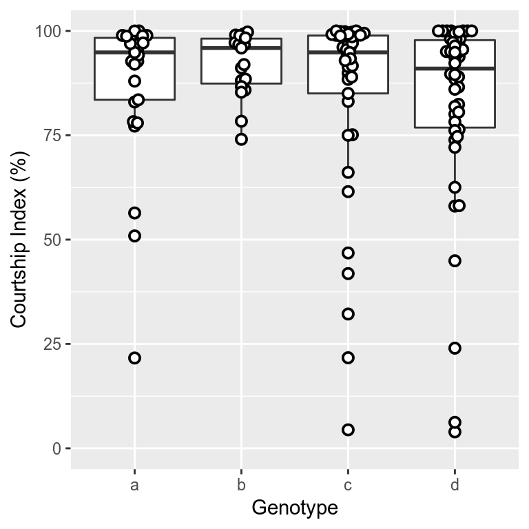

```r
indices <- courting_frames %>%
  filter(sex != "female") %>%
  group_by(uni_fly) %>%
  summarise(genotype = unique(treatment),
            CI = 100*sum(Courtship)/length(Frame),
            CIwF = 100*sum(CourtshipWithFacing)/length(Frame),
            approaching = 100*sum(Approaching)/length(Frame),
            contact = 100*sum(Contact)/length(Frame),
            circling = 100*sum(Encircling)/length(Frame),
            facing = 100*sum(Facing)/length(Frame),
            turning = 100*sum(Turning)/length(Frame),
            wing = 100*sum(WingGesture)/length(Frame)
            )

indices %>%
    ggplot(aes(x=genotype,y=CIwF)) +
    geom_boxplot(outlier.size = 0) +
    geom_beeswarm(shape = 21, colour = "black", fill = "white", size = 2, stroke = 1) +
    ylim(0,100) +
    ylab("Courtship Index (%)") +
    xlab("Genotype")
```

We can look at the individual courtship features to see what they look like. But as with CI, there doesn't look like there is any effect.

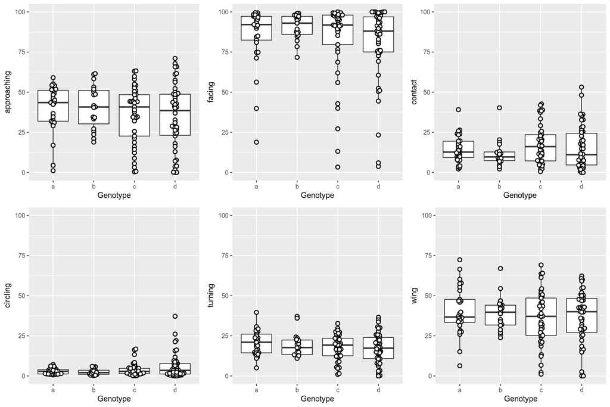

```r
p <- list()
courtship_features <- c("approaching","facing","contact","circling","turning","wing")
for (i in 1:length(courtship_features)) {
    p[[i]] <- indices %>%
        ggplot(aes_string(x="genotype",y=courtship_features[i])) +
        geom_boxplot(outlier.size = 0) +
        geom_beeswarm(shape = 21, colour = "black", fill = "white", size = 2, stroke = 1) +
        #geom_quasirandom(method = "smiley",shape = 21, colour = "black", fill = "white", size = 2, stroke = 1) +
        ylim(0,100) +
        ylab(as.name(courtship_features[i])) +
        xlab("Genotype")
}
plot_grid(plotlist = p,ncol = 3)
```

There also doesn't look like much of an effect on courtship initiation.

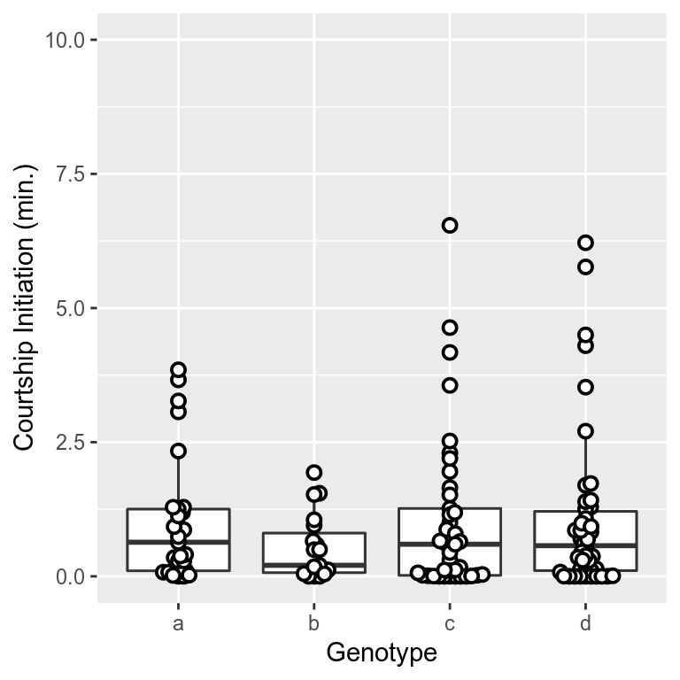

```r
ggplot(start_of_courtship_frames,aes(x=treatment,y=start_of_courtship/1500)) +
    geom_boxplot() +
    ylim(0,10) +
    geom_boxplot(outlier.size = 0) +
    geom_beeswarm(shape = 21, colour = "black", fill = "white", size = 2, stroke = 1) +
    ylab("Courtship Initiation (min.)") +
    xlab("Genotype")
```

There also doesn't look like much of an effect on cumulative copulation.

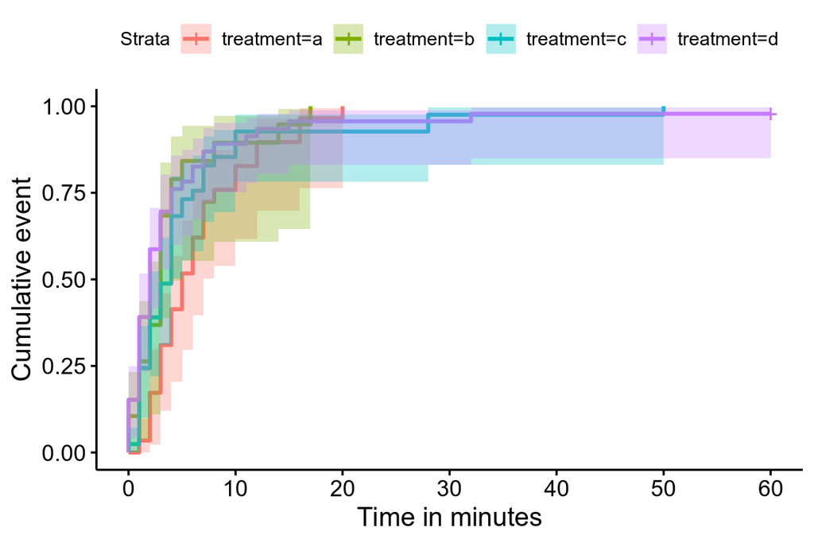

```r
df <- genotypes %>%
  mutate(status = if_else(is.na(copulation_time),0,1))
df$copulation_time <- replace_na(df$copulation_time,3600)
df$copulation_time <- round(as.numeric(df$copulation_time)/60)
fit <- survfit(Surv(copulation_time, status) ~ treatment, data = df)
ggsurv <- ggsurvplot(
            fit,
            data = df,
            risk.table = TRUE,
            pval = FALSE,
            conf.int = TRUE,
            xlim = c(0,60),
            xlab = "Time in minutes",
            break.time.by = 10,
            risk.table.y.text.col = T,
            risk.table.height = 0.25,
            risk.table.y.text = FALSE,
            ncensor.plot = TRUE,
            ncensor.plot.height = 0.25,
            fun = "event"
        )
ggsurv$plot
```

Looking at the position of the female while the male has it's wing extended, also looks quite similar. Which is in contrast to the male aDN experiments. (*NB*: contralateral = left, ipsilateral = right, and the males postion is the centre)

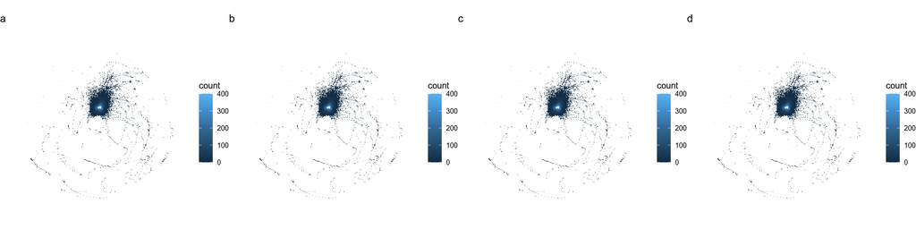

```r
p <- list()
treatment <- c("a","b","c","d")
for (i in 1:length(treatment)) {
    p[[i]] <- courting_frames %>%
                  filter(sex == "male") %>%
                  filter(treatment==treatment[i]) %>%
                  filter(max_wing_ang__rad > (35*pi/180)) %>%
                  ggplot(aes(x=ipsi_contra_rel_x,y=rel_y_other)) +
                  geom_bin2d(bins = c(400,400)) +
                  xlim(-20,20) +
                  ylim(-20,20) +
                  scale_fill_continuous(limits = c(0,400),na.value = "white") +
                  theme_void() +
                  coord_fixed() +
                  ggtitle(treatment[i])
}
plot_grid(plotlist = p,ncol = 4)
```

Here we write a little function to look at the probability density plots of a given feature with a mean trend line and 95% confidence intervals.

```r
mean_pd <- function(input,feature,low=0,high,wing=TRUE,wing_ang=NULL, n=512){
  input <- input %>%
    filter(sex != "female") %>%
    select(uni_fly,Frame,genotype,treatment,sex,feature, max_wing_ang__rad)

  output <- tibble()
  flies <- unique(input$uni_fly)
  for (fly in flies) {
    temp0 <- input %>%
      filter(uni_fly == fly) %>%
      do(
        if(wing)
          filter(., max_wing_ang__rad > wing_ang)
        else
          .
      )
    #message(dim(temp0)[1])
    if(dim(temp0)[1]<100) next

    feat <- temp0[[feature]][!is.na(temp0[[feature]])]
    den <- density(feat, from = low, to = high, n = n, na.rm = TRUE)
    temp1 <- tibble()
    temp1 <- tibble(uni_fly = rep(unique(temp0$uni_fly),length(den[["x"]])),
                    sex = rep(unique(temp0$sex),length(den[["x"]])),
                    genotype = rep(unique(temp0$genotype),length(den[["x"]])),
                    treatment = rep(unique(temp0$treatment),length(den[["x"]])),
                    x = den[["x"]],
                    pd = den[["y"]])
    output <- bind_rows(output,temp1)
  }
  return(output)
}
```

And there isn't anything strikingly different in the density of facing angle.

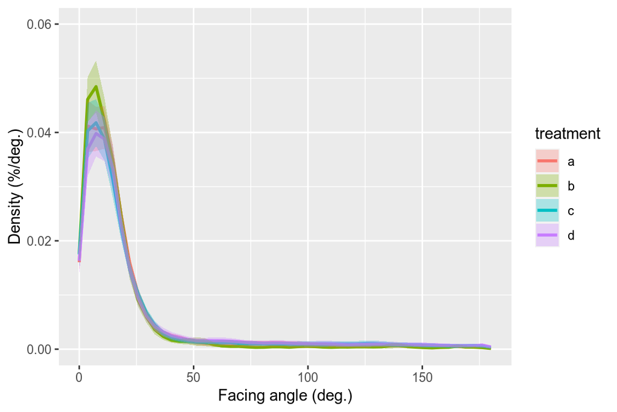

```r
facing_den <- mean_pd(input = courting_frames,feature = "facing_angle__rad",low = 0,high = pi, wing = FALSE, n=50)
facing_den %>%
  filter(sex == "male") %>%
  group_by(treatment,x) %>%
  summarise(y = mean(pd),
            err = qt(0.95,df=length(pd)-1)*sd(pd)/sqrt(length(pd))) %>%
  ggplot(aes(x=x*180/pi, y=y*pi/180)) +
  geom_line(aes(colour=treatment), size=1) +
  geom_ribbon(aes(ymin=if_else(y-err<0,0,y-err)*pi/180, ymax=(y+err)*pi/180, fill=treatment), alpha = 0.3) +
  ylab("Density (%/deg.)") +
  xlab("Facing angle (deg.)") +
  ylim(0,0.06) +
  xlim(0,180)
```

Or distance.

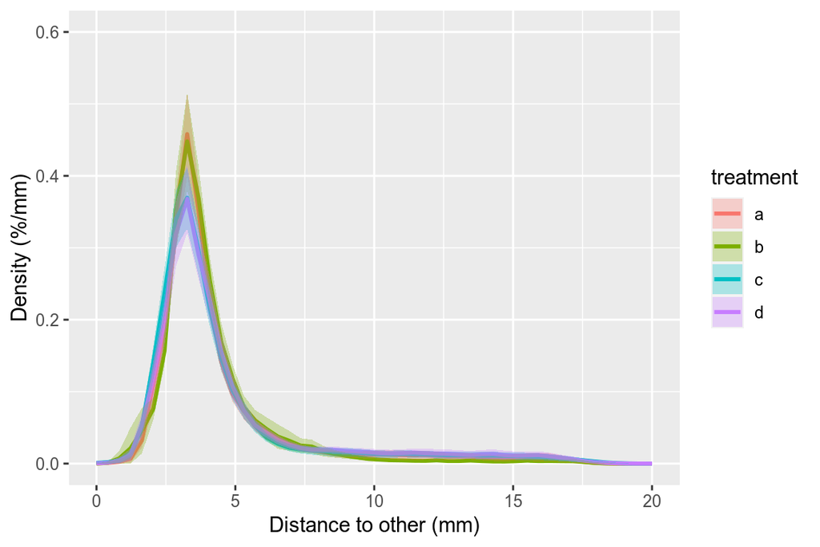

```r
distance_den <- mean_pd(input = courting_frames,feature = "dist_to_other__mm",low = 0,high = 20, wing = FALSE, n=50)
distance_den %>%
  filter(sex == "male") %>%
  group_by(treatment,x) %>%
  summarise(y = mean(pd),
            err = qt(0.95,df=length(pd)-1)*sd(pd)/sqrt(length(pd))) %>%
  ggplot(aes(x=x, y=y)) +
  geom_line(aes(colour=treatment), size=1) +
  geom_ribbon(aes(ymin=if_else(y-err<0,0,y-err), ymax=y+err, fill=treatment), alpha = 0.3) +
  ylab("Density (%/mm)") +
  xlab("Distance to other (mm)") +
  ylim(0,0.6) +
  xlim(0,20)
```

When we quantify the mean facing angle, mean distance to other, and minimum distance to other there is no difference between the flies.

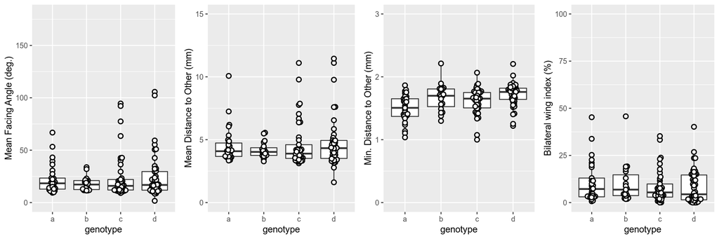

```r
p <- list()
p[[1]] <- courting_frames %>%
  filter(sex != "female") %>%
  group_by(uni_fly) %>%
  summarise(genotype = unique(treatment),
            facing = mean(facing_angle__rad)
  ) %>%
  ggplot(aes(x=genotype,y=facing*180/pi)) +
  geom_boxplot() +
  geom_beeswarm(shape = 21, colour = "black", fill = "white", size = 2, stroke = 1) +
  ylab("Mean Facing Angle (deg.)") +
  ylim(0,180)
p[[2]] <- courting_frames %>%
  filter(sex != "female") %>%
  group_by(uni_fly) %>%
  summarise(mean_dist = mean(dist_to_other__mm),
            genotype = unique(treatment)) %>%
  ggplot(aes(x=genotype, y=mean_dist)) +
  geom_boxplot() +
  geom_beeswarm(shape = 21, colour = "black", fill = "white", size = 2, stroke = 1) +
  ylab("Mean Distance to Other (mm)") +
  ylim(0,15)
p[[3]] <- courting_frames %>%
  filter(sex != "female") %>%
  group_by(uni_fly) %>%
  summarise(min_dist = min(dist_to_other__mm),
            genotype = unique(treatment)) %>%
  ggplot(aes(x=genotype, y=min_dist)) +
  geom_boxplot() +
  geom_beeswarm(shape = 21, colour = "black", fill = "white", size = 2, stroke = 1) +
  ylab("Min. Distance to Other (mm)") +
  ylim(0,3)
p[[4]] <- courting_frames %>%
  filter(sex != "female") %>%
  group_by(genotype) %>%
  group_by(uni_fly) %>%
  summarise(genotype = unique(treatment),
            both_wing_index = 100*sum(min_wing_ang__rad>(15*pi/180), na.rm = TRUE)/
              length(Frame)
  ) %>%
  ggplot(aes(x=genotype, y=both_wing_index)) +
  geom_boxplot() +
  geom_beeswarm(shape = 21, colour = "black", fill = "white", size = 2, stroke = 1) +
  ylab("Bilateral wing index (%)") +
  ylim(0,100)
plot_grid(plotlist = p,ncol = 4)
```

There is no apparent difference in wing choice index ether.

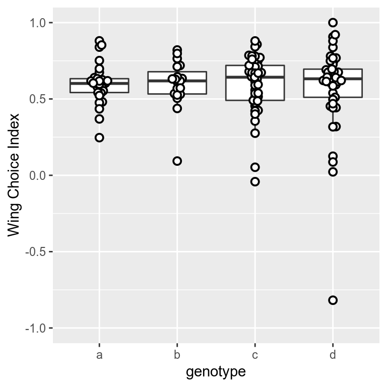

```r
courting_frames %>%
  filter(sex != "female") %>%
  group_by(uni_fly) %>%
  summarise(genotype = unique(treatment),
            wing_choice = (sum(abs(ipsi_wing_ang)>(35*pi/180),na.rm = T)-sum(abs(contra_wing_ang)>(35*pi/180),na.rm = T))/
              (sum(abs(ipsi_wing_ang)>(35*pi/180),na.rm = T)+sum(abs(contra_wing_ang)>(35*pi/180),na.rm = T))
  ) %>%
  ggplot(aes(x=genotype,y=wing_choice)) +
  geom_boxplot() +
  geom_beeswarm(shape = 21, colour = "black", fill = "white", size = 2, stroke = 1) +
  ylab("Wing Choice Index") +
  ylim(-1,1)
```

# **The Stats**

First lets compute a summary table of the features.

```r
court_summary <- courting_frames %>%
  filter(sex!="female") %>%
  group_by(uni_fly) %>%
  summarise(genotype = unique(treatment),
            initiation = min(Frame),
            CI = 100*sum(CourtshipWithFacing)/length(Frame),
            approaching = 100*sum(Approaching)/length(Frame),
            contact = 100*sum(Contact)/length(Frame),
            circling = 100*sum(Encircling)/length(Frame),
            facing = 100*sum(Facing)/length(Frame),
            turning = 100*sum(Turning)/length(Frame),
            wing = 100*sum(WingGesture)/length(Frame),
            time_behind = 100*sum(facing_angle__rad > (25*pi/180))/length(Frame),
            mean_facing_angle = mean(facing_angle__rad),
            mean_dist = mean(dist_to_other__mm),
            min_dist = min(dist_to_other__mm),
            bilateral_wing_index = 100*sum(min_wing_ang__rad>(15*pi/180), na.rm = TRUE)/length(Frame),
            uni_wing_index = 100*sum((max_wing_ang__rad>(35*pi/180) & min_wing_ang__rad < (15*pi/180)), na.rm = TRUE)/length(Frame),
            wing_choice = (sum(abs(ipsi_wing_ang)>(35*pi/180),na.rm = T)-sum(abs(contra_wing_ang)>(35*pi/180),na.rm = T))/
              (sum(abs(ipsi_wing_ang)>(35*pi/180),na.rm = T)+sum(abs(contra_wing_ang)>(35*pi/180),na.rm = T)),
            mean_min_wing = mean(min_wing_ang__rad)*180/pi
            )


temp <- courting_frames %>%
  filter(sex == "male")
uniq_fly <- unique(temp$uni_fly)
bi_wing_bouts <- tibble()
for (fly in uniq_fly) {
  temp2 <- temp %>%
    filter(uni_fly == fly) %>%
    mutate(bin_bilateral_wing = if_else(min_wing_ang__rad>(15*pi/180),1,0)
         )
  temp2$bin_bilateral_wing <- temp2$bin_bilateral_wing %>% replace_na(0)
  bilateral_wing_bouts <- rle(temp2[["bin_bilateral_wing"]])
  temp3 <- tibble(uni_fly = fly,
                  genotype = unique(temp2[["treatment"]]),
                  bilateral_wing_bout_rate = 60*25*sum(bilateral_wing_bouts$values==1)/length(temp2[["Frame"]]),
                  bilateral_wing_bout_length = mean(bilateral_wing_bouts$lengths[bilateral_wing_bouts$values==1])/25
                  )
  bi_wing_bouts <- bind_rows(bi_wing_bouts,temp3)
}
court_summary <- left_join(court_summary,bi_wing_bouts)
head(court_summary)
```

| uni_fly | genotype | initiation | CI | approaching | contact | circling | facing | turning | wing | time_behind | mean_facing_angle | mean_dist | min_dist | bilateral_wing_index | uni_wing_index | wing_choice | mean_min_wing | bilateral_wing_bout_rate | bilateral_wing_bout_length |
| --- | --- | --- | --- | --- | --- | --- | --- | --- | --- | --- | --- | --- | --- | --- | --- | --- | --- | --- | --- |
| Megan-2019_03_06_Courtship-DsxVgluTNT_Female_134_1_10 | a | 953 | 98.33786 | 53.663501 | 9.871099 | 5.1560380 | 97.59159 | 14.654003 | 33.37856 | 6.682497 | 0.2066301 | 3.923973 | 1.651405 | 21.031208 | 31.004071 | 0.8806941 | 8.775749 | 6.614654 | 1.9076923 |
| Megan-2019_03_06_Courtship-DsxVgluTNT_Female_134_1_12 | c | 3451 | 96.09357 | 34.619883 | 4.000000 | 0.5146199 | 94.94737 | 25.730994 | 29.75439 | 13.894737 | 0.2955449 | 4.309247 | 1.727456 | 3.789474 | 23.391813 | 0.7548845 | 5.213410 | 11.228070 | 0.2025000 |
| Megan-2019_03_06_Courtship-DsxVgluTNT_Female_134_1_14 | c | 2478 | 92.42199 | 43.982169 | 18.722140 | 1.4858841 | 91.82764 | 29.717682 | 49.33135 | 16.344725 | 0.3594029 | 4.121979 | 1.657141 | 8.766716 | 40.267459 | 0.6730769 | 5.478634 | 20.059435 | 0.2622222 |
| Megan-2019_03_06_Courtship-DsxVgluTNT_Female_134_1_16 | c | 458 | 61.50583 | 21.208908 | 20.148462 | 4.3478261 | 55.99152 | 20.148462 | 26.19300 | 35.737010 | 0.6986148 | 7.049504 | 1.589272 | 3.711559 | 24.496288 | 0.6796875 | 4.893181 | 3.181336 | 0.7000000 |
| Megan-2019_03_06_Courtship-DsxVgluTNT_Female_134_1_17 | c | 2276 | 46.80769 | 8.794872 | 1.923077 | 0.7820513 | 42.83333 | 5.435897 | 13.24359 | 47.346154 | 0.7426660 | 7.766680 | 1.791870 | 3.256410 | 9.141026 | 0.7149123 | 5.095024 | 10.192308 | 0.1916981 |
| Megan-2019_03_06_Courtship-DsxVgluTNT_Female_134_1_20 | a | 1297 | 98.14964 | 51.112899 | 26.414588 | 3.7275409 | 96.27246 | 27.701797 | 47.70716 | 9.412711 | 0.2241640 | 3.489088 | 1.740000 | 5.417002 | 50.013408 | 0.6256684 | 6.381996 | 18.905873 | 0.1719149 |

And now we calculate a stats table and adjust for multiple comparisons/testing. Although not all the features were plotted above and calculating the stats for all the corresponding figures that we show for the in light experiments.

```r
features <- c("initiation","CI","mean_facing_angle","mean_dist","min_dist","bilateral_wing_index","bilateral_wing_bout_rate",
              "approaching","facing","contact","circling","turning","wing",
              "time_behind","uni_wing_index","bilateral_wing_bout_length","wing_choice")
figures <- c("4a","4b","4g","4h","4i","4j","4k",
             "s4a","s4b","s4c","s4d","s4e","s4f",
             "s4g","s4h","s4i","s4j")
all_pvals <- tibble()
anova_values <- tibble()
for (ii in 1:length(features)) {
  aov <- aov(court_summary[[features[ii]]]~court_summary[["genotype"]])
  temp_anova <- tibble(figure = figures[ii],
                       feature = features[ii],
                       df1 = summary(aov)[[1]][["Df"]][1],
                       df2 = summary(aov)[[1]][["Df"]][2],
                       fvalue = summary(aov)[[1]][["F value"]][1]
                    )
  anova_values <- bind_rows(anova_values,temp_anova)
  if (summary(aov)[[1]][["Pr(>F)"]][[1]]<0.05) {
    d_a <- t.test(court_summary[[features[ii]]][court_summary$genotype=="d"],court_summary[[features[ii]]][court_summary$genotype=="a"])
    d_b <- t.test(court_summary[[features[ii]]][court_summary$genotype=="d"],court_summary[[features[ii]]][court_summary$genotype=="b"])
    d_c <- t.test(court_summary[[features[ii]]][court_summary$genotype=="d"],court_summary[[features[ii]]][court_summary$genotype=="c"])
    temp_pvals <- tibble(figure = figures[ii],
                        feature = features[ii],
                        comparison = c("anova", "d-a t.test", "d-b t.test", "d-c t.test"),
                        pvals = c(summary(aov)[[1]][["Pr(>F)"]][[1]],d_a$p.value,d_b$p.value,d_c$p.value)
                    )
    all_pvals <- bind_rows(all_pvals,temp_pvals)
  } else {
      d_a <- NA
      d_b <- NA
      d_c <- NA
      temp_pvals <- tibble(figure = figures[ii],
                          feature = features[ii],
                          comparison = c("anova", "d-a t.test", "d-b t.test", "d-c t.test"),
                          pvals = c(summary(aov)[[1]][["Pr(>F)"]][[1]],NA,NA,NA)
                      )
      all_pvals <- bind_rows(all_pvals,temp_pvals)
  }
}

res0 <- survdiff(formula = Surv(copulation_time, status) ~ treatment, data = df)
res <- pairwise_survdiff(formula = Surv(copulation_time, status) ~ treatment, data = df, p.adjust.method = "none")
temp_pvals <- tibble(figure = "4c",
                     feature = "copulation",
                     comparison = c("chisq", "d-a log-rank test", "d-b log-rank test", "d-c log-rank test"),
                     pvals = c(1 - pchisq(res0$chisq, length(res0$n) - 1),res[["p.value"]][3,1],res[["p.value"]][3,2],res[["p.value"]][3,3])
                      )
all_pvals <- bind_rows(all_pvals,temp_pvals)

a_pd <- distance_den %>% filter(treatment == "a") %>% group_by(x) %>% summarise(y = mean(pd))
b_pd <- distance_den %>% filter(treatment == "b") %>% group_by(x) %>% summarise(y = mean(pd))
c_pd <- distance_den %>% filter(treatment == "c") %>% group_by(x) %>% summarise(y = mean(pd))
d_pd <- distance_den %>% filter(treatment == "d") %>% group_by(x) %>% summarise(y = mean(pd))
d_a <- ks.test(d_pd$y, a_pd$y, exact = TRUE)
d_b <- ks.test(d_pd$y, b_pd$y, exact = TRUE)
d_c <- ks.test(d_pd$y, c_pd$y, exact = TRUE)

temp_pvals <- tibble(figure = "4e",
                     feature = "dist_to_other",
                     comparison = c("d-a ks test", "d-b ks test", "d-c ks test"),
                     pvals = c(d_a$p.value,d_b$p.value,d_c$p.value)
                    )
all_pvals <- bind_rows(all_pvals,temp_pvals)

a_pd <- facing_den %>% filter(treatment == "a") %>% group_by(x) %>% summarise(y = mean(pd))
b_pd <- facing_den %>% filter(treatment == "b") %>% group_by(x) %>% summarise(y = mean(pd))
c_pd <- facing_den %>% filter(treatment == "c") %>% group_by(x) %>% summarise(y = mean(pd))
d_pd <- facing_den %>% filter(treatment == "d") %>% group_by(x) %>% summarise(y = mean(pd))
d_a <- ks.test(d_pd$y, a_pd$y, exact = TRUE)
d_b <- ks.test(d_pd$y, b_pd$y, exact = TRUE)
d_c <- ks.test(d_pd$y, c_pd$y, exact = TRUE)

temp_pvals <- tibble(figure = "4d",
                     feature = "facing_angle",
                     comparison = c("d-a ks test", "d-b ks test", "d-c ks test"),
                     pvals = c(d_a$p.value,d_b$p.value,d_c$p.value)
                    )
all_pvals <- bind_rows(all_pvals,temp_pvals)

all_pvals <- all_pvals %>%
  mutate(p_adj = p.adjust(pvals,"holm"),
         #sig = ifelse(p_adj<0.05,"y","n"),
         sig_level = ifelse(p_adj>0.1,"ns",
                            ifelse(p_adj>0.05,".",
                                    ifelse(p_adj>0.01,"*",
                                            ifelse(p_adj>0.001,"**",
                                                    ifelse(p_adj>0.001,"***","****")
                                                   )
                                           )
                                    )
                            )
         )
all_pvals <- all_pvals %>% arrange(figure)
all_pvals
```

| figure | feature | comparison | pvals | p_adj | sig_level |
| --- | --- | --- | --- | --- | --- |
| 4a | initiation | anova | 4.913446e-01 | 1.000000e+00 | ns |
| 4a | initiation | d-a t.test | NA | NA | NA |
| 4a | initiation | d-b t.test | NA | NA | NA |
| 4a | initiation | d-c t.test | NA | NA | NA |
| 4b | CI | anova | 3.639968e-01 | 1.000000e+00 | ns |
| 4b | CI | d-a t.test | NA | NA | NA |
| 4b | CI | d-b t.test | NA | NA | NA |
| 4b | CI | d-c t.test | NA | NA | NA |
| 4c | copulation | chisq | 1.396232e-01 | 1.000000e+00 | ns |
| 4c | copulation | d-a log-rank test | 2.533793e-02 | 6.081103e-01 | ns |

[output cut: 68 more lines]

The only features that survive *p*-value adjustment for all comparisons to the experimental line are the probability density plots. But that always happens with this statistical test. Either it's not the most appropriate test, or the resolution I've used isn't appropriate and the data is "over sampled". Eitherway, for everything else the conclusion is no significant differences.